# Covid ’19 Analysis

2025-01-29

#### Fellow CU Boulder peers reviewing these work, scroll down to Costa Rica COVID19 Data Analysis to skip the code we already reviewed in class

```r
library(tidyverse)
library(janitor)
library(lubridate)
```

```r
url <- "https://raw.githubusercontent.com/CSSEGISandData/COVID-19/master/csse_covid_19_data/csse_covid_19_time_series/"

global_cases <- url %>%
  str_c("time_series_covid19_confirmed_global.csv") %>%
  read_csv()
global_deaths <- url %>%
  str_c("time_series_covid19_deaths_global.csv") %>%
  read_csv()
us_cases <- url %>%
  str_c("time_series_covid19_confirmed_US.csv") %>%
  read_csv()
us_deaths <- url %>%
  str_c("time_series_covid19_deaths_US.csv") %>%
  read_csv()
cols <- c('Province/State', 'Country/Region', 'Lat', 'Long')

global_cases <- global_cases %>%
    pivot_longer(cols = -cols,
                 names_to = "date",
                 values_to = "cases") %>%
    select(-c(Lat,Long)) %>%
  clean_names()
global_deaths <- global_deaths %>%
    pivot_longer(cols = -cols,
                 names_to = "date",
                 values_to = "deaths") %>%
    select(-c(Lat,Long)) %>%
  clean_names()
```

```r
global <- global_cases %>%
  full_join(global_deaths) %>%
  mutate(date = mdy(date))
global <- global %>% filter(cases > 0)

summary(global)
```

```
##  province_state     country_region          date                cases
##  Length:306827      Length:306827      Min.   :2020-01-22   Min.   :        1
##  Class :character   Class :character   1st Qu.:2020-12-12   1st Qu.:     1316
##  Mode  :character   Mode  :character   Median :2021-09-16   Median :    20365
##                                        Mean   :2021-09-11   Mean   :  1032863
##                                        3rd Qu.:2022-06-15   3rd Qu.:   271281
##                                        Max.   :2023-03-09   Max.   :103802702
##      deaths
##  Min.   :      0
##  1st Qu.:      7
##  Median :    214
##  Mean   :  14405
##  3rd Qu.:   3665
##  Max.   :1123836
```

```r
global %>% filter(cases > 28000000, country_region == "US")
```

```
## # A tibble: 751 × 5
##    province_state country_region date          cases deaths
##    <chr>          <chr>          <date>        <dbl>  <dbl>
##  1 <NA>           US             2021-02-17 28009004 489731
##  2 <NA>           US             2021-02-18 28081254 492289
##  3 <NA>           US             2021-02-19 28156128 494810
##  4 <NA>           US             2021-02-20 28229709 496711
##  5 <NA>           US             2021-02-21 28284962 497922
##  6 <NA>           US             2021-02-22 28341018 499127
##  7 <NA>           US             2021-02-23 28414848 501384
##  8 <NA>           US             2021-02-24 28489829 504596
##  9 <NA>           US             2021-02-25 28566889 507105
## 10 <NA>           US             2021-02-26 28641812 509227
## # ℹ 741 more rows
```

```r
us_cases <- us_cases %>%
  pivot_longer(cols = -(UID:Combined_Key),
               names_to = "date",
               values_to = "cases") %>%
  select(Admin2:cases) %>%
  mutate(date = mdy(date)) %>%
  select(-c(Lat, Long_))

us_deaths <- us_deaths %>%
  pivot_longer(cols = -(UID:Population),
               names_to = "date",
               values_to = "deaths") %>%
  select(Admin2:deaths) %>%
  mutate(date = mdy(date)) %>%
  select(-c(Lat, Long_))

us <- us_cases %>%
  full_join(us_deaths) %>%
  clean_names()
```

[output not shown]

```r
us
```

```
## # A tibble: 3,819,906 × 8
##    admin2 province_state country_region combined_key date       cases population
##    <chr>  <chr>          <chr>          <chr>        <date>     <dbl>      <dbl>
##  1 Autau… Alabama        US             Autauga, Al… 2020-01-22     0      55869
##  2 Autau… Alabama        US             Autauga, Al… 2020-01-23     0      55869
##  3 Autau… Alabama        US             Autauga, Al… 2020-01-24     0      55869
##  4 Autau… Alabama        US             Autauga, Al… 2020-01-25     0      55869
##  5 Autau… Alabama        US             Autauga, Al… 2020-01-26     0      55869
##  6 Autau… Alabama        US             Autauga, Al… 2020-01-27     0      55869
##  7 Autau… Alabama        US             Autauga, Al… 2020-01-28     0      55869
##  8 Autau… Alabama        US             Autauga, Al… 2020-01-29     0      55869
##  9 Autau… Alabama        US             Autauga, Al… 2020-01-30     0      55869
## 10 Autau… Alabama        US             Autauga, Al… 2020-01-31     0      55869
## # ℹ 3,819,896 more rows
## # ℹ 1 more variable: deaths <dbl>
```

```r
global <- global %>%
  unite("combined_key",
        c(province_state, country_region),
        sep = ", ",
        na.rm = TRUE,
        remove = FALSE)


uid <- str_c(
  "https://raw.githubusercontent.com/CSSEGISandData/COVID-19/master/csse_covid_19_data/",
        "UID_ISO_FIPS_LookUp_Table.csv") %>%
  read_csv() %>%
  select(-c(Lat, Long_, Combined_Key, code3, iso2, iso3, Admin2)) %>%
  clean_names()
global <- global %>%
  left_join(uid, by = c("province_state", "country_region")) %>%
  select(province_state, country_region, date, cases, deaths,
         population, combined_key)
```

```r
us_by_state <- us %>%
  group_by(province_state, country_region, date) %>%
  summarise(cases = sum(cases),
            deaths = sum(deaths),
            population = sum(population)) %>%
  mutate(deaths_per_mill = deaths*1000000/population) %>%
  ungroup()
us_by_state
```

```
## # A tibble: 66,294 × 7
##    province_state country_region date       cases deaths population
##    <chr>          <chr>          <date>     <dbl>  <dbl>      <dbl>
##  1 Alabama        US             2020-01-22     0      0    4903185
##  2 Alabama        US             2020-01-23     0      0    4903185
##  3 Alabama        US             2020-01-24     0      0    4903185
##  4 Alabama        US             2020-01-25     0      0    4903185
##  5 Alabama        US             2020-01-26     0      0    4903185
##  6 Alabama        US             2020-01-27     0      0    4903185
##  7 Alabama        US             2020-01-28     0      0    4903185
##  8 Alabama        US             2020-01-29     0      0    4903185
##  9 Alabama        US             2020-01-30     0      0    4903185
## 10 Alabama        US             2020-01-31     0      0    4903185
## # ℹ 66,284 more rows
## # ℹ 1 more variable: deaths_per_mill <dbl>
```

```r
us_totals <- us_by_state %>%
  group_by(country_region, date) %>%
  summarise(cases = sum(cases),
            deaths = sum(deaths),
            population = sum(population)) %>%
  mutate(deaths_per_mill = deaths*1000000/population) %>%
  ungroup()
```

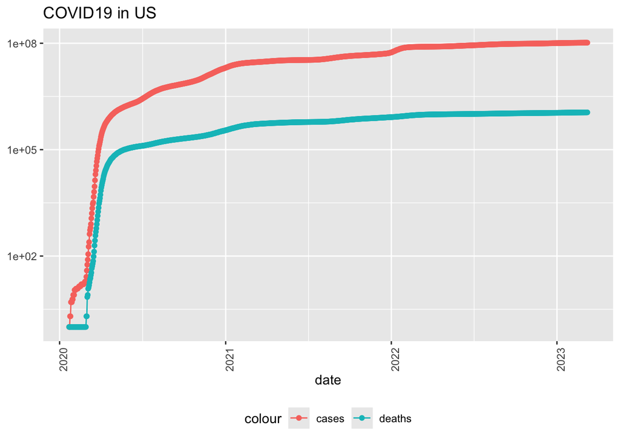

```r
us_totals %>%
  filter(cases > 0) %>%
  ggplot(aes(date, cases)) +
  geom_line(aes(color = "cases")) +
  geom_point(aes(color = "cases")) +
  geom_line(aes(y = deaths, color="deaths")) +
  geom_point(aes(y = deaths, color = "deaths"))+
  scale_y_log10()+
  theme(legend.position = "bottom",
        axis.text.x = element_text(angle=90))+
  labs(title = "COVID19 in US", y=NULL)
```

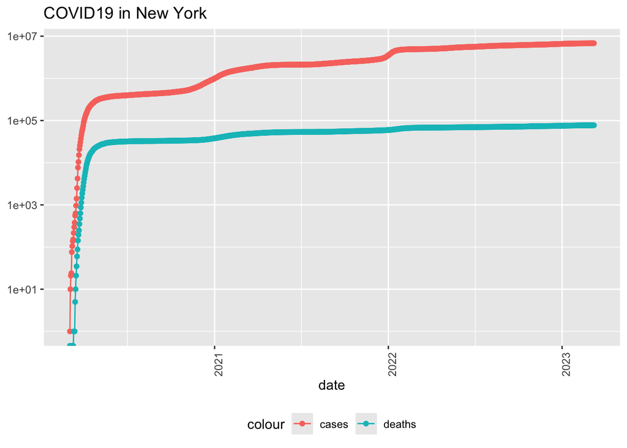

```r
us_by_state %>%
  filter(province_state == "New York") %>%
  filter(cases > 0) %>%
  ggplot(aes(date, cases)) +
  geom_line(aes(color = "cases")) +
  geom_point(aes(color = "cases")) +
  geom_line(aes(y = deaths, color="deaths")) +
  geom_point(aes(y = deaths, color = "deaths"))+
  scale_y_log10()+
  theme(legend.position = "bottom",
        axis.text.x = element_text(angle=90))+
  labs(title = "COVID19 in New York", y=NULL)
```

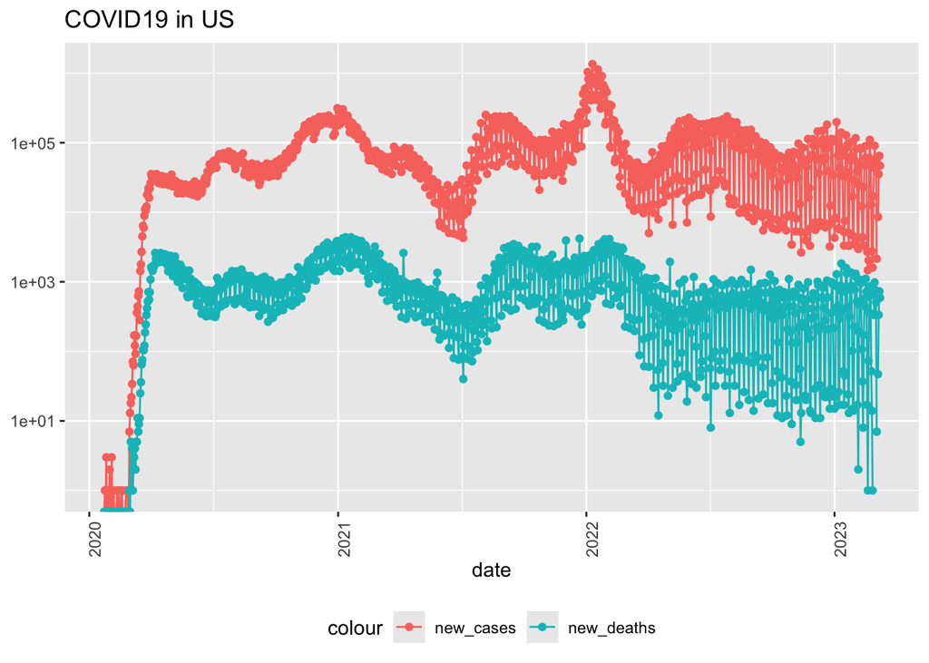

```r
us_by_state <- us_by_state %>%
  mutate(new_cases = cases - lag(cases),
         new_deaths = deaths - lag(deaths))
us_totals <- us_totals %>%
  mutate(new_cases = cases - lag(cases),
         new_deaths = deaths - lag(deaths))

us_totals %>%
  ggplot(aes(date, new_cases)) +
  geom_line(aes(color = "new_cases")) +
  geom_point(aes(color = "new_cases")) +
  geom_line(aes(y = new_deaths, color="new_deaths")) +
  geom_point(aes(y = new_deaths, color = "new_deaths"))+
  scale_y_log10()+
  theme(legend.position = "bottom",
        axis.text.x = element_text(angle=90))+
  labs(title = "COVID19 in US", y=NULL)
```

```r
us_state_totals <- us_by_state %>%
  group_by(province_state) %>%
  summarize(deaths = max(deaths),
            cases = max(cases),
            population = max(population),
            cases_per_thou = 1000* cases/population,
            deaths_per_thou = 1000* deaths/population) %>%
  filter(cases>0, population>0)

us_state_totals %>%
  slice_min(deaths_per_thou, n=10)
```

```
## # A tibble: 10 × 6
##    province_state        deaths  cases population cases_per_thou deaths_per_thou
##    <chr>                  <dbl>  <dbl>      <dbl>          <dbl>           <dbl>
##  1 American Samoa            34 8.32e3      55641           150.           0.611
##  2 Northern Mariana Isl…     41 1.37e4      55144           248.           0.744
##  3 Virgin Islands           130 2.48e4     107268           231.           1.21
##  4 Hawaii                  1841 3.81e5    1415872           269.           1.30
##  5 Vermont                  929 1.53e5     623989           245.           1.49
##  6 Puerto Rico             5823 1.10e6    3754939           293.           1.55
##  7 Utah                    5298 1.09e6    3205958           340.           1.65
##  8 Alaska                  1486 3.08e5     740995           415.           2.01
##  9 District of Columbia    1432 1.78e5     705749           252.           2.03
## 10 Washington             15683 1.93e6    7614893           253.           2.06
```

```r
us_state_totals %>%
  slice_max(deaths_per_thou, n=10)
```

```
## # A tibble: 10 × 6
##    province_state deaths   cases population cases_per_thou deaths_per_thou
##    <chr>           <dbl>   <dbl>      <dbl>          <dbl>           <dbl>
##  1 Arizona         33102 2443514    7278717           336.            4.55
##  2 Oklahoma        17972 1290929    3956971           326.            4.54
##  3 Mississippi     13370  990756    2976149           333.            4.49
##  4 West Virginia    7960  642760    1792147           359.            4.44
##  5 New Mexico       9061  670929    2096829           320.            4.32
##  6 Arkansas        13020 1006883    3017804           334.            4.31
##  7 Alabama         21032 1644533    4903185           335.            4.29
##  8 Tennessee       29263 2515130    6829174           368.            4.28
##  9 Michigan        42205 3064125    9986857           307.            4.23
## 10 Kentucky        18130 1718471    4467673           385.            4.06
```

```r
mod <- lm(deaths_per_thou ~ cases_per_thou, data = us_state_totals)
summary(mod)
```

```
##
## Call:
## lm(formula = deaths_per_thou ~ cases_per_thou, data = us_state_totals)
##
## Residuals:
##     Min      1Q  Median      3Q     Max
## -2.3352 -0.5978  0.1491  0.6535  1.2086
##
## Coefficients:
##                Estimate Std. Error t value Pr(>|t|)
## (Intercept)    -0.36167    0.72480  -0.499     0.62
## cases_per_thou  0.01133    0.00232   4.881 9.76e-06 ***
## ---
## Signif. codes:  0 '***' 0.001 '**' 0.01 '*' 0.05 '.' 0.1 ' ' 1
##
## Residual standard error: 0.8615 on 54 degrees of freedom
## Multiple R-squared:  0.3061, Adjusted R-squared:  0.2933
## F-statistic: 23.82 on 1 and 54 DF,  p-value: 9.763e-06
```

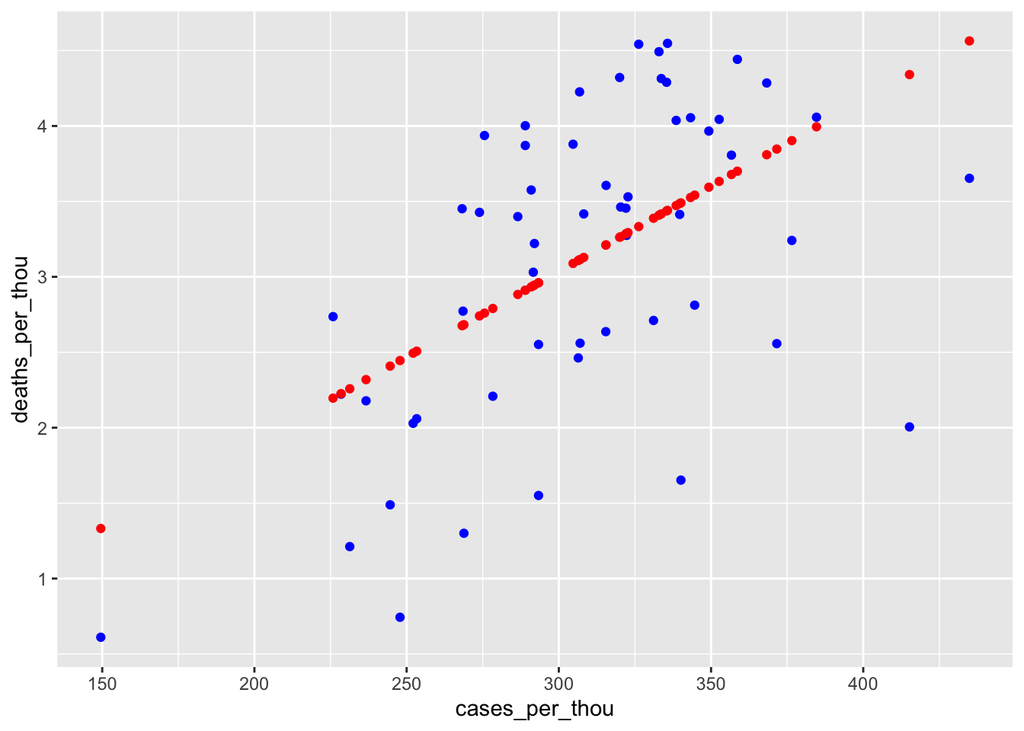

```r
us_tot_w_pred <- us_state_totals %>%
  mutate(pred = predict(mod))

us_tot_w_pred %>%
  ggplot() +
  geom_point(aes(x = cases_per_thou, y = deaths_per_thou), color = "blue") +
  geom_point(aes(x = cases_per_thou, y = pred), color = "red")
```

# Costa Rica COVID19 Data Analysis

For this analysis, you will learn more about the COVID19 Pandemic as it develop in Costa Rica.

```r
cr <- global %>%
  filter(country_region == "Costa Rica") %>%
  mutate(new_cases = cases - lag(cases),
         new_deaths = deaths - lag(deaths)) %>%
  select(-c(province_state, country_region, combined_key)) # Dropping province_state because all NAs

cr_monthly <- cr %>%
  group_by(month = floor_date(date, unit = "month")) %>%
  summarize(cases = sum(cases),
            new_cases = sum(new_cases),
            deaths = sum(deaths),
            new_deaths = sum(new_deaths),
            population = max(population)) %>%
  ungroup()


cr_monthly
```

```
## # A tibble: 37 × 6
##    month        cases new_cases deaths new_deaths population
##    <date>       <dbl>     <dbl>  <dbl>      <dbl>      <dbl>
##  1 2020-03-01    2987        NA     24         NA    5094114
##  2 2020-04-01   17866       372    122          4    5094114
##  3 2020-05-01   26697       337    260          4    5094114
##  4 2020-06-01   58319      2403    356          6    5094114
##  5 2020-07-01  309536     14361   1823        134    5094114
##  6 2020-08-01  890542     23467   9155        286    5094114
##  7 2020-09-01 1771225     34473  19556        468    5094114
##  8 2020-10-01 2901099     34211  35904        481    5094114
##  9 2020-11-01 3734891     29667  46733        341    5094114
## 10 2020-12-01 4796194     29683  60628        459    5094114
## # ℹ 27 more rows
```

## Visualizing Costa Rica during the pandemic

[figure not shown]

```r
cr_monthly %>%
  ggplot(aes(x = month)) +
  geom_line(aes(y = new_cases, color = "New Cases"), size = 1.2) +  # Line for new cases
  geom_line(aes(y = new_deaths, color = "Deaths"), size = 1.2) +        # Line for deaths
  scale_y_log10() +  # Log10 scale for y-axis with comma formatting
  labs(
    title = "Costa Rica monthly COVID-19 new cases and new deaths",
    subtitle = "Tracking the rise and fall of new cases and new deaths over time",
    x = "Month",
    y = "Count (Log10 Scale)",
    color = "Metric",  # Legend title
    caption = "Data Source: Your Data Source Here"
  ) +
  scale_color_manual(values = c("New Cases" = "darkgreen", "Deaths" = "red")) +  # Custom colors
  theme_minimal() +  # Start with a minimal theme
  theme(
    plot.title = element_text(size = 20, face = "bold", color = "black", hjust = 0.5),
    plot.subtitle = element_text(size = 14, color = "gray40", hjust = 0.5),
    plot.caption = element_text(size = 10, color = "gray40", hjust = 1),
    axis.title = element_text(size = 14, face = "bold", color = "black"),
    axis.text = element_text(size = 12, color = "black"),
    panel.background = element_rect(fill = "white"),  # Light background
    plot.background = element_rect(fill = "white"),   # Light background
    panel.grid.major = element_line(color = "gray90"),  # Light grid lines
    panel.grid.minor = element_blank(),  # Remove minor grid lines
    text = element_text(color = "black"),  # Black text for contrast
    legend.position = "bottom"  # Move legend to the bottom
  )+
  geom_smooth(aes(y = new_cases, color = "New Cases Trend"),
              method = "lm", formula = y ~ poly(x, 2), se = FALSE, linetype = "dashed") +  # Quadratic trend for cases
  geom_smooth(aes(y = new_deaths, color = "Deaths Trend"),
              method = "lm", formula = y ~ poly(x, 2), se = FALSE, linetype = "dashed")   # Quadratic trend for deaths
```

The quadratic trend for the deaths seems to have a stronger curvature indicating the deaths dropped faster than the new cases and will be explored further with in the modeling part.

But first, a break down analysis of the seasonal trend, to identify if their were specific months higher than others.

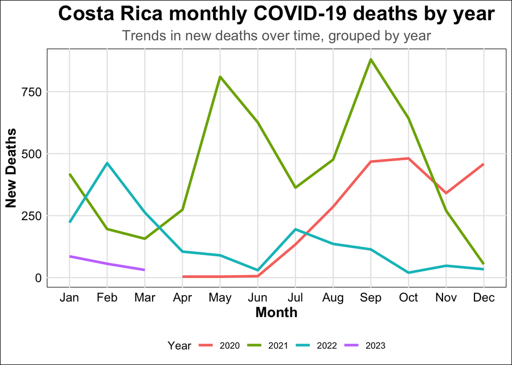

```r
cr_monthly %>%
  mutate(
    month_num = as.factor(month(month, label = TRUE, abbr = TRUE)),  # Convert month to ordered factor
    year = as.factor(year(month))  # Convert year to factor
  ) %>%
  ggplot(aes(x = month_num, y = new_deaths, color = year, group = year)) +  # Group by year
  geom_line(size = 1.2) +  # Add lines
  labs(
    title = "Costa Rica monthly COVID-19 deaths by year",
    subtitle = "Trends in new deaths over time, grouped by year",
    x = "Month",
    y = "New Deaths",
    color = "Year",  # Legend title
  ) +
  theme_minimal() +  # Start with a minimal theme
  theme(
    plot.title = element_text(size = 20, face = "bold", color = "black", hjust = 0.5),
    plot.subtitle = element_text(size = 14, color = "gray40", hjust = 0.5),
    plot.caption = element_text(size = 10, color = "gray40", hjust = 1),
    axis.title = element_text(size = 14, face = "bold", color = "black"),
    axis.text = element_text(size = 12, color = "black"),
    panel.background = element_rect(fill = "white"),  # Light background
    plot.background = element_rect(fill = "white"),   # Light background
    panel.grid.major = element_line(color = "gray90"),  # Light grid lines
    panel.grid.minor = element_blank(),  # Remove minor grid lines
    text = element_text(color = "black"),  # Black text for contrast
    legend.position = "bottom"  # Move legend to the bottom
  )
```

The graph shows May and September of 2021 as the deadliest months of the COVID19th pandemic in Costa Rica.

## Modeling Costa Rica

### Simple linear model

```r
cr_monthly <- cr_monthly %>%
  mutate(days_since_start = as.numeric(month - min(month)))
mod_lin <- lm(new_deaths ~ days_since_start, cr_monthly)
summary(mod_lin)
```

```
##
## Call:
## lm(formula = new_deaths ~ days_since_start, data = cr_monthly)
##
## Residuals:
##     Min      1Q  Median      3Q     Max
## -366.44 -122.89  -55.51  112.99  620.10
##
## Coefficients:
##                  Estimate Std. Error t value Pr(>|t|)
## (Intercept)      377.0525    77.5513   4.862 2.59e-05 ***
## days_since_start  -0.2134     0.1200  -1.778   0.0843 .
## ---
## Signif. codes:  0 '***' 0.001 '**' 0.01 '*' 0.05 '.' 0.1 ' ' 1
##
## Residual standard error: 227.6 on 34 degrees of freedom
##   (1 observation deleted due to missingness)
## Multiple R-squared:  0.08511,    Adjusted R-squared:  0.0582
## F-statistic: 3.163 on 1 and 34 DF,  p-value: 0.08427
```

A simple linear model of the new_deaths over time shows a weak fit, the key takeaways are:

- The model explains only 8.5% of the variance in deaths (R-squared=0.085).
- The negative coefficient for days_since_start (-0.21) suggests a slight decrease in deaths over time, but this effect is not statistically significant (p=0.084).

Time alone, as a linear predictor, does not meaningfully explain trends in COVID-19 deaths.

### Quadratic Model

```r
mod_quad <- lm(new_deaths ~ days_since_start + I(days_since_start^2), cr_monthly)
summary(mod_quad)
```

```
##
## Call:
## lm(formula = new_deaths ~ days_since_start + I(days_since_start^2),
##     data = cr_monthly)
##
## Residuals:
##    Min     1Q Median     3Q    Max
## -328.8 -127.6  -29.6  115.8  469.3
##
## Coefficients:
##                         Estimate Std. Error t value Pr(>|t|)
## (Intercept)           47.5732080 96.9923376   0.490 0.627037
## days_since_start       1.4916530  0.3965207   3.762 0.000658 ***
## I(days_since_start^2) -0.0015123  0.0003411  -4.433  9.7e-05 ***
## ---
## Signif. codes:  0 '***' 0.001 '**' 0.01 '*' 0.05 '.' 0.1 ' ' 1
##
## Residual standard error: 182.9 on 33 degrees of freedom
##   (1 observation deleted due to missingness)
## Multiple R-squared:  0.4266, Adjusted R-squared:  0.3918
## F-statistic: 12.28 on 2 and 33 DF,  p-value: 0.0001034
```

By including the time variable as quadratic predictor, a strong improvement is found. They key differences are:

- The model explains 42.7% of the variance (R-squared=0.427), a 5x improvement over the linear model.
- Both the linear term (p=0.0007) and quadratic term (p<0.0001) are highly significant.

Interpretation:

- Positive linear coefficient (1.49): Deaths initially increase with time.
- Negative quadratic coefficient (-0.0015): After a peak, deaths decrease over time.
- The model captures a wave-like pattern (e.g., a surge followed by decline), common in pandemics like COVID-19.

## Conclusion

After modeling the data, a non-Linear trend was discovered. The quadratic term helped in capturing the true relationship between time and deaths. Further analysis and more data is needed to arrive at a strong conclusion but the wave-like pattern could reflect public health interventions (e.g., lock downs, vaccinations) impacting death rates over time.